# Mobility Before and After COVID-19

Juthi Dewan, Son Phan

## Distribution of rides over time

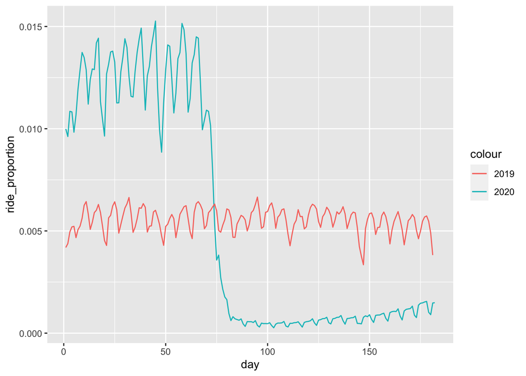

```r
ride_ct_weeks_20 <- rides_20_h1clean %>%
    count(day) %>%
    mutate(total_rides = nrow(rides_20_h1clean),
                 ride_proportion = n/total_rides)

ride_ct_weeks_19 <- rides_19_h1_sample %>%
    count(day) %>%
    mutate(total_rides = nrow(rides_19_h1_sample),
                 ride_proportion = n/total_rides)

ggplot() +
    geom_line(data = ride_ct_weeks_20, mapping = aes(x = day, y = ride_proportion, color="2020")) +
    geom_line(data = ride_ct_weeks_19, mapping = aes(x = day, y = ride_proportion, color="2019"))
```

## Distribution of rides over space

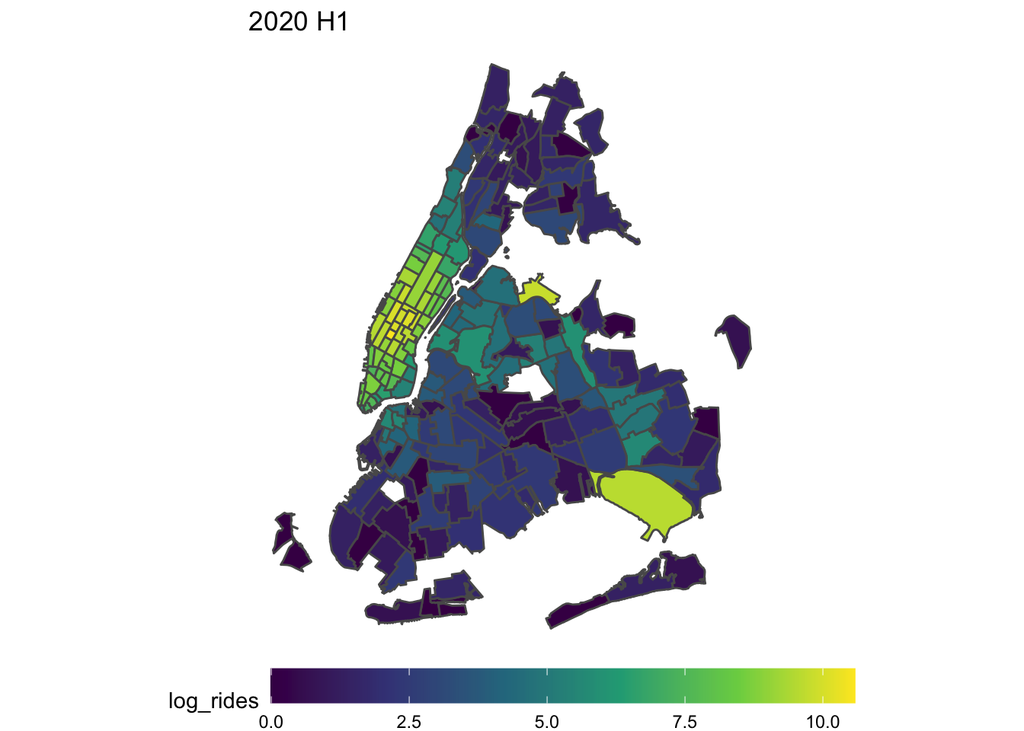

```r
# Seems to be outliers in Manhattan obviously
rides_20_h1clean %>%
    filter(DOLocationID == 230) %>%
    count(PULocationID) %>%
    mutate(total_rides = sum(n),
                 ride_proportion = n/total_rides,
                 log_rides = log(n)) %>%
    left_join(x = ., y = taxi_zones, by = c("PULocationID" = "LocationID")) %>%
    ggplot(mapping = aes(geometry = geometry)) +
    geom_sf(mapping = aes(fill = log_rides)) +
    theme_map +
    scale_fill_viridis_c() +
    theme(legend.position="bottom") +
    guides(fill = guide_colourbar(barwidth = 20)) + ggtitle("2020 H1")
```

## Comparing changes in trip_time between 2019 H1 and 2020 H1

Only consider the top 50-ish origins amongst the 2 years.

```r
top_origins_20 = rides_20_h1clean %>%
    filter(DOLocationID == 230) %>%
    count(PULocationID) %>%
  arrange(-n) %>%
  filter(row_number() <= 50) %>% pull(PULocationID)

top_origins_19 = rides_19_h1_sample %>%
    filter(DOLocationID == 230) %>%
    count(PULocationID) %>%
  arrange(-n) %>%
  filter(row_number() <= 50) %>% pull(PULocationID)

top_origins = union(top_origins_20, top_origins_19)

rides_20_h1_ts = rides_20_h1clean %>%
    filter(DOLocationID == 230,
           PULocationID %in% top_origins) %>%
  group_by(PULocationID) %>%
  summarise(
    n_trips = n(),
    mean_trip_time = mean(trip_time),
    median_trip_time = median(trip_time),
    log_mean_trip_time = log(mean_trip_time),
    log_median_trip_time = log(median_trip_time),
    mean_speed = mean(speed),
    median_speed = median(speed)
  )
rides_19_h1_ts = rides_19_h1_sample %>%
    filter(DOLocationID == 230,
           PULocationID %in% top_origins) %>%
  group_by(PULocationID) %>%
  summarise(
    mean_trip_time = mean(trip_time),
    median_trip_time = median(trip_time),
    log_mean_trip_time = log(mean_trip_time),
    log_median_tripl_time = log(median_trip_time),
    mean_speed = mean(speed),
    median_speed = median(speed)
  )
```

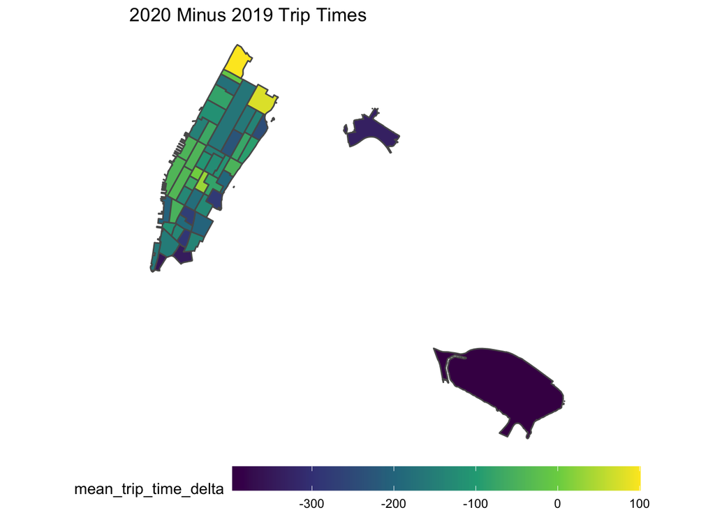

```r
rides_h1_ts_delta = left_join(x = rides_19_h1_ts, y = rides_20_h1_ts, by = c("PULocationID" = "PULocationID")) %>%
  mutate(mean_trip_time_delta = mean_trip_time.y - mean_trip_time.x)

rides_h1_ts_delta %>%
  filter(!(abs(mean_trip_time_delta - mean(mean_trip_time_delta)) > 2*sd(mean_trip_time_delta))) %>%
    left_join(x = ., y = taxi_zones, by = c("PULocationID" = "LocationID")) %>%
    ggplot(mapping = aes(geometry = geometry)) +
    geom_sf(mapping = aes(fill = mean_trip_time_delta)) +
    theme_map +
    scale_fill_viridis_c() +
    theme(legend.position="bottom") +
    guides(fill = guide_colourbar(barwidth = 20)) + ggtitle("2020 Minus 2019 Trip Times")
```

## Simple Model - Just by Year

```r
rides_20_h1_top_origins <- rides_20_h1clean %>%
  filter(DOLocationID == 230, PULocationID %in% top_origins)

rides_19_h1_top_origins <- rides_19_h1_sample %>%
  filter(DOLocationID == 230, PULocationID %in% top_origins)

rides_h1_top_origins = bind_rows(rides_20_h1_top_origins, rides_19_h1_top_origins) %>%
  filter(year %in% c(2019, 2020)) %>%
  mutate(PULocationID = factor(PULocationID),
         year = factor(year))

## Weibull
trip_time_year_weibull = survreg(formula = Surv(trip_time) ~ factor(year), dist = "weibull", data = rides_h1_top_origins)
trip_time_year_weibull %>% summary()
```

```
##
## Call:
## survreg(formula = Surv(trip_time) ~ factor(year), data = rides_h1_top_origins,
##     dist = "weibull")
##                     Value Std. Error      z      p
## (Intercept)       6.96019    0.00176 3959.6 <2e-16
## factor(year)2020 -0.14447    0.00235  -61.6 <2e-16
## Log(scale)        0.09256    0.00059  156.9 <2e-16
##
## Scale= 1.1
##
## Weibull distribution
## Loglik(model)= -6963844   Loglik(intercept only)= -6965738
##  Chisq= 3786.51 on 1 degrees of freedom, p= 0
## Number of Newton-Raphson Iterations: 5
## n= 876992
```

```r
wei_19_trip_time_SC = function(x) pweibull(q = x, shape = 1/trip_time_year_weibull$scale, scale = exp(trip_time_year_weibull$coefficients[1] + trip_time_year_weibull$coefficients[2]*0), lower.tail = FALSE)

wei_20_trip_time_SC = function(x) pweibull(q = x, shape = 1/trip_time_year_weibull$scale, scale = exp(trip_time_year_weibull$coefficients[1] + trip_time_year_weibull$coefficients[2]*1), lower.tail = FALSE)

## Log-normal
trip_time_year_lnorm = survreg(formula = Surv(trip_time) ~ factor(year), dist = "lognormal", data = rides_h1_top_origins)
trip_time_year_lnorm %>% summary()
```

```
##
## Call:
## survreg(formula = Surv(trip_time) ~ factor(year), data = rides_h1_top_origins,
##     dist = "lognormal")
##                      Value Std. Error      z      p
## (Intercept)       6.530057   0.001279 5104.9 <2e-16
## factor(year)2020 -0.099109   0.001761  -56.3 <2e-16
## Log(scale)       -0.194446   0.000755 -257.5 <2e-16
##
## Scale= 0.823
##
## Log Normal distribution
## Loglik(model)= -6754814   Loglik(intercept only)= -6756395
##  Chisq= 3161.83 on 1 degrees of freedom, p= 0
## Number of Newton-Raphson Iterations: 2
## n= 876992
```

```r
lnorm_19_trip_time_SC = function(x) plnorm(q = x, meanlog = trip_time_year_lnorm$coefficients[1] + trip_time_year_lnorm$coefficients[2]*0, sdlog = trip_time_year_lnorm$scale, lower.tail = FALSE)

lnorm_20_trip_time_SC = function(x) plnorm(q = x, meanlog = trip_time_year_lnorm$coefficients[1] + trip_time_year_lnorm$coefficients[2]*1, sdlog = trip_time_year_lnorm$scale, lower.tail = FALSE)

## Cox PH
trip_time_year_coxPH = coxph(formula = Surv(trip_time) ~ factor(year), data = rides_h1_top_origins)
trip_time_year_coxPH %>% summary()
```

```
## Call:
## coxph(formula = Surv(trip_time) ~ factor(year), data = rides_h1_top_origins)
##
##   n= 876992, number of events= 876992
##
##                      coef exp(coef) se(coef)     z Pr(>|z|)
## factor(year)2020 0.143931  1.154805 0.002145 67.11   <2e-16 ***
## ---
## Signif. codes:  0 '***' 0.001 '**' 0.01 '*' 0.05 '.' 0.1 ' ' 1
##
##                  exp(coef) exp(-coef) lower .95 upper .95
## factor(year)2020     1.155     0.8659      1.15      1.16
##
## Concordance= 0.517  (se = 0 )
## Likelihood ratio test= 4512  on 1 df,   p=<2e-16
## Wald test            = 4504  on 1 df,   p=<2e-16
## Score (logrank) test = 4511  on 1 df,   p=<2e-16
```

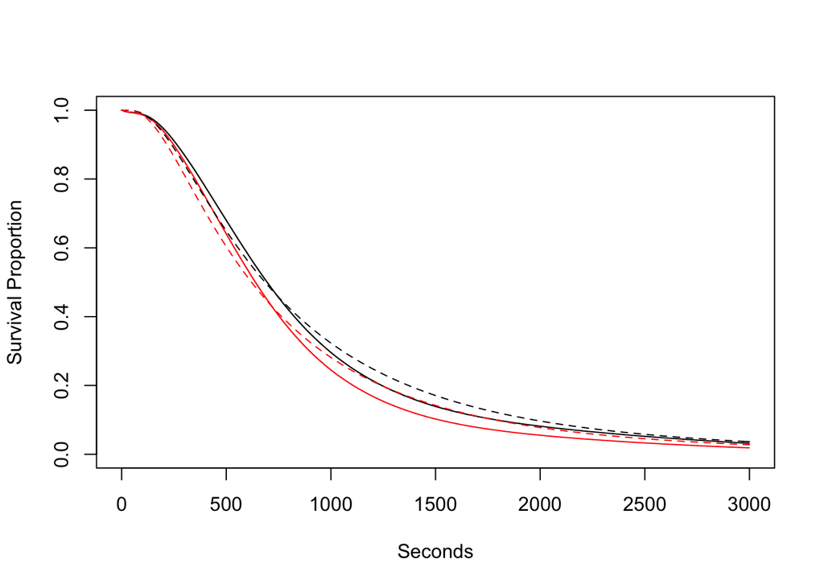

```r
plot(survfit(trip_time_year_coxPH, newdata = data.frame(year = c("2019" , "2020"))), xlab = "Seconds", ylab = "Survival Proportion", col=1:2, xlim=c(0, 3000))
curve(lnorm_19_trip_time_SC, lty=2, add=TRUE)
curve(lnorm_20_trip_time_SC, col=2, lty=2, add=TRUE)
```

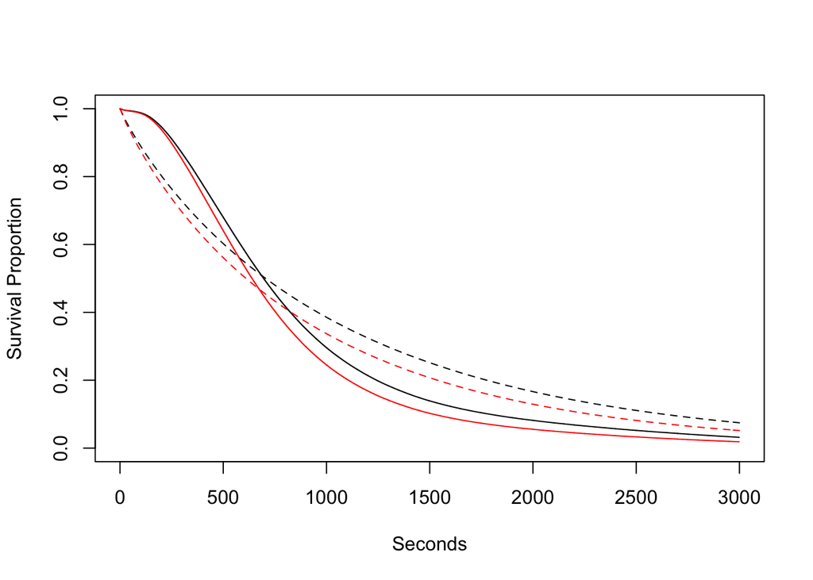

```r
plot(survfit(trip_time_year_coxPH, newdata = data.frame(year = c("2019" , "2020"))), xlab = "Seconds", ylab = "Survival Proportion", col=1:2, xlim=c(0, 3000))
curve(wei_19_trip_time_SC, lty=2, add=TRUE)
curve(wei_20_trip_time_SC, col=2, lty=2, add=TRUE)
```

## Complex Model - Year AND Zone

Question: If trips got FASTER in 2020 relative to 2019, did some zones speed up more? did any zones get actually slower? Can we discern a pattern to these changes in space?

Takes a long time to run; be careful before running. There’s lots of output that we’re gonna have to parse through and kind of summarize in a way. One thing I thought about was maybe testing another variable like distance and seeing if some of the covariates become insignificant. This would tell us if there is another explanatory variable confounding with simply sorting out PULocationID’s.

```r
## Weibull
trip_time_yearzone_weibull = survreg(formula = Surv(trip_time) ~ year*PULocationID, dist = "weibull", data = rides_h1_top_origins)
trip_time_yearzone_weibull %>% summary()
```

```
##
## Call:
## survreg(formula = Surv(trip_time) ~ year * PULocationID, data = rides_h1_top_origins,
##     dist = "weibull")
##                              Value Std. Error      z       p
## (Intercept)               7.532211   0.017245 436.79 < 2e-16
## year2020                 -0.091317   0.023808  -3.84 0.00013
## PULocationID24           -0.236067   0.047356  -4.98 6.2e-07
## PULocationID43           -0.506328   0.020556 -24.63 < 2e-16
## PULocationID45            0.234416   0.043985   5.33 9.9e-08
## PULocationID48           -1.326023   0.018690 -70.95 < 2e-16
## PULocationID50           -1.105420   0.021684 -50.98 < 2e-16
## PULocationID68           -0.785241   0.019520 -40.23 < 2e-16
## PULocationID75           -0.271283   0.041741  -6.50 8.1e-11
## PULocationID79           -0.254101   0.023032 -11.03 < 2e-16
## PULocationID87           -0.139133   0.029932  -4.65 3.3e-06
## PULocationID88            0.275073   0.034946   7.87 3.5e-15
## PULocationID90           -0.808145   0.021119 -38.27 < 2e-16
## PULocationID100          -1.302349   0.018676 -69.73 < 2e-16
## PULocationID107          -0.495236   0.022288 -22.22 < 2e-16
## PULocationID113          -0.407903   0.023043 -17.70 < 2e-16
## PULocationID114          -0.365652   0.024488 -14.93 < 2e-16
## PULocationID125          -0.349507   0.031273 -11.18 < 2e-16
## PULocationID132           0.645158   0.019149  33.69 < 2e-16
## PULocationID137          -0.511785   0.026988 -18.96 < 2e-16
## PULocationID138           0.358532   0.018712  19.16 < 2e-16
## PULocationID140          -0.334952   0.027107 -12.36 < 2e-16
## PULocationID141          -0.527972   0.023629 -22.34 < 2e-16
## PULocationID142          -1.011596   0.018951 -53.38 < 2e-16
## PULocationID143          -0.824283   0.022447 -36.72 < 2e-16
## PULocationID144           0.025939   0.025148   1.03 0.30234
## PULocationID148          -0.122485   0.028304  -4.33 1.5e-05
## PULocationID151          -0.378445   0.030630 -12.36 < 2e-16
## PULocationID158          -0.451614   0.025277 -17.87 < 2e-16
## PULocationID161          -0.957797   0.018622 -51.43 < 2e-16
## PULocationID162          -0.806295   0.018965 -42.51 < 2e-16
## PULocationID163          -0.971555   0.019050 -51.00 < 2e-16
## PULocationID164          -0.934771   0.019316 -48.39 < 2e-16
## PULocationID166          -0.175117   0.041900  -4.18 2.9e-05
## PULocationID170          -0.818524   0.019493 -41.99 < 2e-16
```

[output cut: 61 more lines]

```
## year2020:PULocationID246  0.041800   0.027489   1.52 0.12835
## year2020:PULocationID249  0.040446   0.030391   1.33 0.18324
## year2020:PULocationID261 -0.081902   0.033952  -2.41 0.01585
## year2020:PULocationID262 -0.082769   0.041577  -1.99 0.04651
## year2020:PULocationID263 -0.018510   0.039102  -0.47 0.63594
## year2020:PULocationID264  0.079255   0.051079   1.55 0.12075
## Log(scale)                0.050758   0.000532  95.50 < 2e-16
##
## Scale= 1.05
##
## Weibull distribution
## Loglik(model)= -6862884   Loglik(intercept only)= -6965738
##  Chisq= 205707.9 on 101 degrees of freedom, p= 0
## Number of Newton-Raphson Iterations: 4
## n= 876992
```

```r
#2020 trip duration in mins
Duration_2020 <-
  rides_20_h1clean%>%
  mutate(Pickup = tpep_pickup_datetime,Dropoff = tpep_dropoff_datetime) %>%
  select(-c(tpep_pickup_datetime, tpep_dropoff_datetime)) %>%
  mutate(Duration = difftime(Dropoff, Pickup, units = "mins"))

#2019 trip duration in mins
Duration_2019h1 <-
  rides_19_h1_sample%>%
  mutate(Pickup = tpep_pickup_datetime,Dropoff = tpep_dropoff_datetime) %>%
  select(-c(tpep_pickup_datetime, tpep_dropoff_datetime)) %>%
  mutate(Duration = difftime(Dropoff, Pickup, units = "mins"))

Duration_2019h2 <-
  rides_19_h2_sample%>%
  mutate(Pickup = tpep_pickup_datetime,Dropoff = tpep_dropoff_datetime) %>%
  select(-c(tpep_pickup_datetime, tpep_dropoff_datetime)) %>%
  mutate(Duration = difftime(Dropoff, Pickup, units = "mins"))
```

```r
sample_2020 <- Duration_2020 %>%
    sample_n(size = 10000)

sample_2019h1 <- Duration_2019h1 %>%
    sample_n(size = 10000)

sample_2019h2 <- Duration_2019h2 %>%
    sample_n(size = 10000)
```

```r
#weekly trip duration mean
weeklyAvg20 <-
  sample_2020 %>%
  group_by(week) %>%
  mutate(weeklyAvg = mean(Duration))

weeklyAvg19h1 <-
  sample_2019h1 %>%
  group_by(week) %>%
  mutate(weeklyAvg = mean(Duration))
```

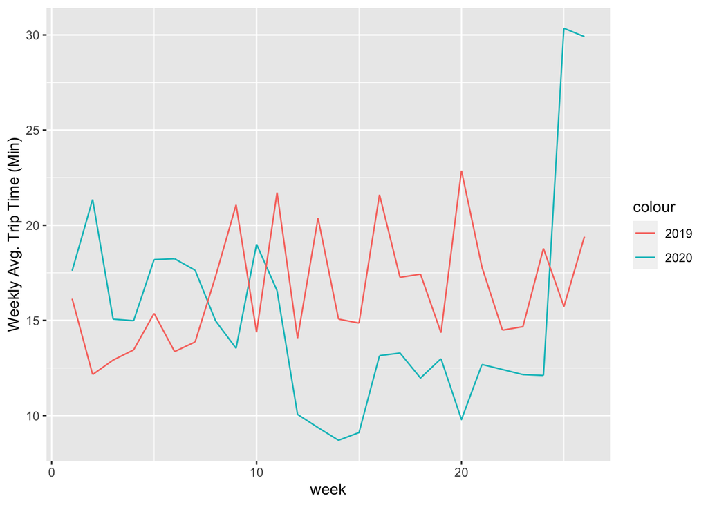

```r
#trip duration by week in 2020 vs 2019
ggplot() +
    geom_line(data = weeklyAvg20, mapping = aes(x = week, y = weeklyAvg, color="2020")) +
    geom_line(data = weeklyAvg19h1, mapping = aes(x = week, y = weeklyAvg, color="2019")) + ylab("Weekly Avg. Trip Time (Min)")
```